# R Notebook

# Caso Facturas online

## Paquetes a usar

```r
library(tidyverse)
library(DBI)
library(RMariaDB)
library(openxlsx)
library(lubridate)
library(data.table)
```

## Importar Data

R se conectará a una base de datos para obtener los datos a usar en el presente ejemplo

### Conectarse con la base de datos

```r
con <- dbConnect(RMariaDB::MariaDB(),
                 user= "root",
                 password= "1234",
                 dbname= "see_test")
dbListTables(con)
```

```
## [1] "cajero"        "productos"     "satisfaccion"  "sucursal"
## [5] "transacciones"
```

### Ejecutar un query en la base de datos

```r
transacciones <-  dbGetQuery(con, "
                             SELECT trns.*, prod.Description
                             FROM transacciones trns
                             LEFT JOIN productos prod
                             on trns.StockCode = prod.StockCode
                             ")
dim(transacciones)
```

```
## [1] 6080    8
```

```r
glimpse(transacciones)
```

```
## Observations: 6,080
## Variables: 8
## $ InvoiceNo   <chr> "536876", "537237", "537434", "538566", "538827", ...
## $ StockCode   <chr> "22609", "22609", "22609", "22609", "22609", "2260...
## $ Quantity    <dbl> 3, 2, 1, 2, 72, 72, 36, 108, 144, 180, 36, 36, 36,...
## $ InvoiceDate <chr> "12/3/2010 11:36", "12/6/2010 9:58", "12/6/2010 16...
## $ UnitPrice   <dbl> 166, 166, 166, 166, 21, 21, 21, 21, 21, 21, 21, 21...
## $ CustomerID  <dbl> NA, NA, NA, NA, 14298, 14913, 16316, 14298, 13253,...
## $ Country     <chr> "United Kingdom", "United Kingdom", "United Kingdo...
## $ Description <chr> "PENS ASSORTED SPACEBALL", "PENS ASSORTED SPACEBAL...
```

### Corregir datos

```r
transacciones <- transacciones %>%
  mutate(InvoiceDate = parse_date_time(InvoiceDate, orders=c("mdY HM")) )
glimpse(transacciones)
```

```
## Observations: 6,080
## Variables: 8
## $ InvoiceNo   <chr> "536876", "537237", "537434", "538566", "538827", ...
## $ StockCode   <chr> "22609", "22609", "22609", "22609", "22609", "2260...
## $ Quantity    <dbl> 3, 2, 1, 2, 72, 72, 36, 108, 144, 180, 36, 36, 36,...
## $ InvoiceDate <dttm> 2010-12-03 11:36:00, 2010-12-06 09:58:00, 2010-12...
## $ UnitPrice   <dbl> 166, 166, 166, 166, 21, 21, 21, 21, 21, 21, 21, 21...
## $ CustomerID  <dbl> NA, NA, NA, NA, 14298, 14913, 16316, 14298, 13253,...
## $ Country     <chr> "United Kingdom", "United Kingdom", "United Kingdo...
## $ Description <chr> "PENS ASSORTED SPACEBALL", "PENS ASSORTED SPACEBAL...
```

## Reporte 1: Venta por País

Se quiere ver la evolución de la venta mensual de cada país, de tal forma que cada fila representa un país-año y en las columnas se tiene los meses de venta.

Primero obtenemos la venta resumida por país, año y mes

```r
transacciones %>%
  group_by( Country, Anio= year(InvoiceDate), Mes= month(InvoiceDate)) %>%
  summarise( venta_usd= sum( Quantity * UnitPrice ))
```

| Country | Anio | Mes | venta_usd |
| --- | --- | --- | --- |
| Australia | 2011 | 2 | 8112 |
| Australia | 2011 | 4 | 210 |
| Australia | 2011 | 6 | 50432 |
| Australia | 2011 | 7 | 1734 |
| Australia | 2011 | 8 | 13568 |
| Australia | 2011 | 9 | 7146 |
| Australia | 2011 | 10 | 25520 |
| Austria | 2010 | 12 | 1160 |
| Austria | 2011 | 5 | 1170 |
| Austria | 2011 | 7 | 1734 |

[output cut: 163 more lines]

Ahora vamos a pasar el mes a ser columna

```r
transacciones %>%
  group_by( Country, Anio= year(InvoiceDate), Mes= month(InvoiceDate)) %>%
  summarise( venta_usd= sum( Quantity * UnitPrice , na.rm = TRUE)) %>%
  arrange(  Mes, Anio, Country) %>%
  pivot_wider(values_from = venta_usd, names_from = Mes)
```

| Country | Anio | 1 | 2 | 3 | 4 | 5 | 6 | 7 | 8 | 9 | 10 | 11 | 12 |
| --- | --- | --- | --- | --- | --- | --- | --- | --- | --- | --- | --- | --- | --- |
| EIRE | 2011 | 6230 | 32000 | 8756 | 11240 | 28586 | 34359 | 178860 | 10703 | 58394 | -3102 | 54010 | 3980 |
| France | 2011 | 1944 | 1658 | 3881 | 2255 | 3950 | 21364 | 6372 | 9640 | 17801 | 21072 | 17872 | 2259 |
| Germany | 2011 | 29617 | 2445 | 13410 | 9706 | 40107 | 14615 | 12088 | 11399 | 9109 | 27781 | 15028 | 1141 |
| Hong Kong | 2011 | 525 | NA | NA | NA | NA | NA | NA | 2000 | NA | 1170 | NA | NA |
| Italy | 2011 | 2550 | 210 | NA | NA | 210 | NA | NA | 210 | NA | 3960 | 9509 | NA |
| Lebanon | 2011 | 252 | NA | NA | NA | NA | NA | NA | NA | NA | NA | NA | NA |
| Netherlands | 2011 | 28140 | 40208 | 26766 | NA | 18000 | 415 | NA | 23904 | 56908 | 26400 | 125 | NA |
| Portugal | 2011 | 2080 | 1530 | 252 | NA | NA | NA | NA | NA | 1040 | 5938 | 1248 | 1326 |
| Spain | 2011 | 2634 | 2430 | NA | 1040 | 126 | 1160 | 465 | 1350 | 2000 | 4272 | 2834 | 130 |
| Switzerland | 2011 | 2796 | 1160 | NA | NA | 2340 | NA | NA | 1626 | 3468 | 255 | 18364 | NA |

[output cut: 33 more lines]

Pero ahora piden tener una columna con el total del año de cada país y que en el reporte aparezca el país de mayor a menos por venta.

```r
transacciones %>%
  group_by( Country, Anio= year(InvoiceDate), Mes= month(InvoiceDate)) %>%
  summarise( venta_usd= sum( Quantity * UnitPrice )) %>%
  group_by( Country) %>%
  mutate( TotalPais= sum(venta_usd, na.rm = TRUE)) %>%
  group_by( Country, Anio) %>%
  mutate( TotalPaisAnio= sum(venta_usd, na.rm = TRUE)) %>%
  arrange(  Mes, Anio, Country) %>%
  pivot_wider(values_from = venta_usd, names_from = Mes) %>%
  arrange(  -TotalPais, Country, -Anio) %>%
  select( -TotalPais )
```

| Country | Anio | TotalPaisAnio | 1 | 2 | 3 | 4 | 5 | 6 | 7 | 8 | 9 | 10 | 11 | 12 |
| --- | --- | --- | --- | --- | --- | --- | --- | --- | --- | --- | --- | --- | --- | --- |
| United Kingdom | 2011 | 6482935 | 454648 | 482990 | 561849 | 386766 | 561209 | 577401 | 674057 | 434966 | 686896 | 544039 | 858189 | 259925 |
| United Kingdom | 2010 | 591759 | NA | NA | NA | NA | NA | NA | NA | NA | NA | NA | NA | 591759 |
| EIRE | 2011 | 424016 | 6230 | 32000 | 8756 | 11240 | 28586 | 34359 | 178860 | 10703 | 58394 | -3102 | 54010 | 3980 |
| EIRE | 2010 | 1530 | NA | NA | NA | NA | NA | NA | NA | NA | NA | NA | NA | 1530 |
| Netherlands | 2011 | 220866 | 28140 | 40208 | 26766 | NA | 18000 | 415 | NA | 23904 | 56908 | 26400 | 125 | NA |
| Germany | 2011 | 186446 | 29617 | 2445 | 13410 | 9706 | 40107 | 14615 | 12088 | 11399 | 9109 | 27781 | 15028 | 1141 |
| Germany | 2010 | 14484 | NA | NA | NA | NA | NA | NA | NA | NA | NA | NA | NA | 14484 |
| France | 2011 | 110068 | 1944 | 1658 | 3881 | 2255 | 3950 | 21364 | 6372 | 9640 | 17801 | 21072 | 17872 | 2259 |
| France | 2010 | 252 | NA | NA | NA | NA | NA | NA | NA | NA | NA | NA | NA | 252 |
| Australia | 2011 | 106722 | NA | 8112 | NA | 210 | NA | 50432 | 1734 | 13568 | 7146 | 25520 | NA | NA |

[output cut: 33 more lines]

Ahora que ya tenemos el reporte final, lo guardamos en un objeto de R para luego llamarlo cuando se vaya a exportar

```r
rpt_porPais <- transacciones %>%
  group_by( Country, Anio= year(InvoiceDate), Mes= month(InvoiceDate)) %>%
  summarise( venta_usd= sum( Quantity * UnitPrice )) %>%
  group_by( Country) %>%
  mutate( TotalPais= sum(venta_usd, na.rm = TRUE)) %>%
  group_by( Country, Anio) %>%
  mutate( TotalPaisAnio= sum(venta_usd, na.rm = TRUE)) %>%
  arrange(  Mes, Anio, Country) %>%
  pivot_wider(values_from = venta_usd, names_from = Mes) %>%
  arrange(  -TotalPais, Country, -Anio) %>%
  select( -TotalPais )
# Mostrar primeras filas
head(rpt_porPais)
```

| Country | Anio | TotalPaisAnio | 1 | 2 | 3 | 4 | 5 | 6 | 7 | 8 | 9 | 10 | 11 | 12 |
| --- | --- | --- | --- | --- | --- | --- | --- | --- | --- | --- | --- | --- | --- | --- |
| United Kingdom | 2011 | 6482935 | 454648 | 482990 | 561849 | 386766 | 561209 | 577401 | 674057 | 434966 | 686896 | 544039 | 858189 | 259925 |
| United Kingdom | 2010 | 591759 | NA | NA | NA | NA | NA | NA | NA | NA | NA | NA | NA | 591759 |
| EIRE | 2011 | 424016 | 6230 | 32000 | 8756 | 11240 | 28586 | 34359 | 178860 | 10703 | 58394 | -3102 | 54010 | 3980 |
| EIRE | 2010 | 1530 | NA | NA | NA | NA | NA | NA | NA | NA | NA | NA | NA | 1530 |
| Netherlands | 2011 | 220866 | 28140 | 40208 | 26766 | NA | 18000 | 415 | NA | 23904 | 56908 | 26400 | 125 | NA |
| Germany | 2011 | 186446 | 29617 | 2445 | 13410 | 9706 | 40107 | 14615 | 12088 | 11399 | 9109 | 27781 | 15028 | 1141 |

## Reporte 2: Analisis por Producto

Se quiere ver un indicador de diciembre 2011 vs diciembre 2010, diciembre 2011 vs promedio de enero a noviembre de 2011.

Primero obtenemos la venta resumida por producto, año y mes

```r
transacciones %>%
  group_by( StockCode, Description, Anio= year(InvoiceDate), Mes= month(InvoiceDate)) %>%
  summarise( venta_usd= sum( Quantity * UnitPrice ))
```

| StockCode | Description | Anio | Mes | venta_usd |
| --- | --- | --- | --- | --- |
| 16218 | CARTOON PENCIL SHARPENERS | 2010 | 12 | 719 |
| 16218 | CARTOON PENCIL SHARPENERS | 2011 | 2 | 1280 |
| 16218 | CARTOON PENCIL SHARPENERS | 2011 | 3 | 1488 |
| 16218 | CARTOON PENCIL SHARPENERS | 2011 | 4 | 2000 |
| 16218 | CARTOON PENCIL SHARPENERS | 2011 | 5 | 160 |
| 16218 | CARTOON PENCIL SHARPENERS | 2011 | 6 | 7498 |
| 16218 | CARTOON PENCIL SHARPENERS | 2011 | 7 | 2010 |
| 16218 | CARTOON PENCIL SHARPENERS | 2011 | 8 | 1920 |
| 16218 | CARTOON PENCIL SHARPENERS | 2011 | 9 | 4320 |
| 16218 | CARTOON PENCIL SHARPENERS | 2011 | 10 | 2376 |

[output cut: 472 more lines]

Ahora vamos a calcular la venta de dic-2011, dic-2010, promedio ene-nov 2011

```r
transacciones %>%
  group_by( StockCode, Description, Anio= year(InvoiceDate), Mes= month(InvoiceDate)) %>%
  summarise( venta_usd= sum( Quantity * UnitPrice )) %>%
  group_by( StockCode, Description) %>%
  summarise(
    Dic_2011= sum( ifelse( Anio== 2011 & Mes==12 , venta_usd, 0) , na.rm= TRUE),
    Dic_2010= sum( ifelse( Anio== 2010 & Mes==12 , venta_usd, 0) , na.rm= TRUE),
    Promedio2011= sum( ifelse( Anio== 2011 & Mes!=12 , venta_usd, 0)/11 , na.rm= TRUE),
    ) %>%
  arrange(-Promedio2011)
```

| StockCode | Description | Dic_2011 | Dic_2010 | Promedio2011 |
| --- | --- | --- | --- | --- |
| 84078A | SET/4 WHITE RETRO STORAGE CUBES | 17814 | 105515 | 126197.81818 |
| 23236 | STORAGE TIN VINTAGE DOILY | 10410 | 0 | 62788.54545 |
| 82600 | NO SINGING METAL SIGN | 61834 | 44265 | 60055.36364 |
| 22179 | SET 10 NIGHT OWL LIGHTS | 50457 | 76534 | 52582.63636 |
| 22767 | TRIPLE PHOTO FRAME CORNICE | 24875 | 20943 | 49537.45455 |
| 20979 | 36 PENCILS TUBE RED RETROSPOT | 3815 | 19500 | 39062.09091 |
| 23131 | MISTLETOE HEART WREATH CREAM | 1245 | 0 | 34570.72727 |
| 22433 | WATERING CAN GREEN DINOSAUR | 1583 | 6559 | 23456.63636 |
| 22964 | 3 PIECE SPACEBOY COOKIE CUTTER SET | 5278 | 7571 | 23221.36364 |
| 22773 | GREEN DRAWER KNOB ACRYLIC EDWARDIAN | 5976 | 36087 | 20847.90909 |

[output cut: 40 more lines]

Nuevamente, habiendo llegado a lo que queremos, pasamos a guardarlo en un objeto

```r
rpt_porProducto <- transacciones %>%
  group_by( StockCode, Description, Anio= year(InvoiceDate), Mes= month(InvoiceDate)) %>%
  summarise( venta_usd= sum( Quantity * UnitPrice )) %>%
  group_by( StockCode, Description) %>%
  summarise(
    Dic_2011= sum( ifelse( Anio== 2011 & Mes==12 , venta_usd, 0) , na.rm= TRUE),
    Dic_2010= sum( ifelse( Anio== 2010 & Mes==12 , venta_usd, 0) , na.rm= TRUE),
    Promedio2011= sum( ifelse( Anio== 2011 & Mes!=12 , venta_usd, 0)/11 , na.rm= TRUE),
    ) %>%
  arrange(-Promedio2011)
head(rpt_porProducto)
```

| StockCode | Description | Dic_2011 | Dic_2010 | Promedio2011 |
| --- | --- | --- | --- | --- |
| 84078A | SET/4 WHITE RETRO STORAGE CUBES | 17814 | 105515 | 126197.82 |
| 23236 | STORAGE TIN VINTAGE DOILY | 10410 | 0 | 62788.55 |
| 82600 | NO SINGING METAL SIGN | 61834 | 44265 | 60055.36 |
| 22179 | SET 10 NIGHT OWL LIGHTS | 50457 | 76534 | 52582.64 |
| 22767 | TRIPLE PHOTO FRAME CORNICE | 24875 | 20943 | 49537.45 |
| 20979 | 36 PENCILS TUBE RED RETROSPOT | 3815 | 19500 | 39062.09 |

## Reporte 3: Reino Unido

Se quiere ver la evolución de la venta mensual en dólares y transacciones de “United Kingdom”

Primero obtenemos la venta y cantidad de facutras para “United Kingdom” por año y mes

```r
transacciones %>%
  filter(Country== "United Kingdom") %>%
  group_by( Country, Anio= year(InvoiceDate), Mes= month(InvoiceDate)) %>%
  summarise(
    venta_usd= sum( Quantity * UnitPrice ),
    n_facturas= n_distinct(InvoiceNo),
    )
```

| Country | Anio | Mes | venta_usd | n_facturas |
| --- | --- | --- | --- | --- |
| United Kingdom | 2010 | 12 | 591759 | 264 |
| United Kingdom | 2011 | 1 | 454648 | 240 |
| United Kingdom | 2011 | 2 | 482990 | 239 |
| United Kingdom | 2011 | 3 | 561849 | 285 |
| United Kingdom | 2011 | 4 | 386766 | 254 |
| United Kingdom | 2011 | 5 | 561209 | 300 |
| United Kingdom | 2011 | 6 | 577401 | 303 |
| United Kingdom | 2011 | 7 | 674057 | 285 |
| United Kingdom | 2011 | 8 | 434966 | 253 |
| United Kingdom | 2011 | 9 | 686896 | 350 |

[output cut: 3 more lines]

Procedemos a guardarlo en un objeto

```r
rpt_UnitedKingdom <- transacciones %>%
  filter(Country== "United Kingdom") %>%
  group_by( Country, Anio= year(InvoiceDate), Mes= month(InvoiceDate)) %>%
  summarise(
    venta_usd= sum( Quantity * UnitPrice ),
    n_facturas= n_distinct(InvoiceNo),
    )
```

Y se construye el gráfico respectivo

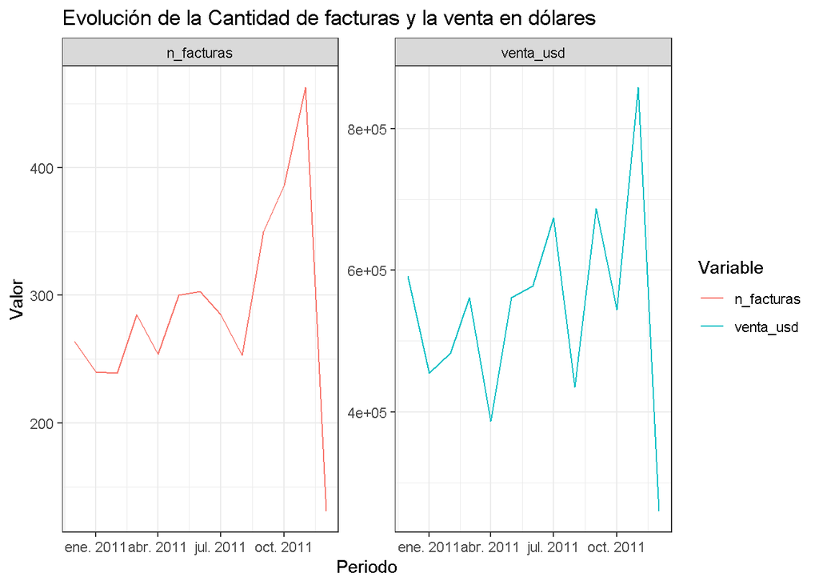

```r
rpt_UnitedKingdom %>%
  mutate(Periodo= ymd(Anio*10000+Mes*100+01)) %>%
  pivot_longer(c("venta_usd", "n_facturas"), names_to = "Variable", values_to= "Valor") %>%
  ggplot( aes(x= Periodo, color= Variable)) +
  geom_line( aes(y= Valor)) +
  facet_wrap( "Variable", scales = "free") +
  theme_bw() +
  labs(title = "Evolución de la Cantidad de facturas y la venta en dólares ")
```

## Exportar a Excel

### Agregar fórmulas en excel

```r
dt_porProducto <- data.table(rpt_porProducto)
dt_UnitedKingdom <- data.table(rpt_UnitedKingdom)
## Agregar fórmula
dt_porProducto[,':='(VarDic= paste0("IFERROR( (C", (1:nrow(dt_porProducto))+5, "-D", (1:nrow(dt_porProducto))+5,
                               ')/D',(1:nrow(dt_porProducto))+5, ",0)"))]
dt_porProducto[,':='(VarProm2011= paste0("IFERROR( (C", (1:nrow(dt_porProducto))+5, "-E", (1:nrow(dt_porProducto))+5,
                               ')/E',(1:nrow(dt_porProducto))+5, ",0)"))]
head(dt_porProducto)
```

| StockCode | Description | Dic_2011 | Dic_2010 | Promedio2011 | VarDic | VarProm2011 |
| --- | --- | --- | --- | --- | --- | --- |
| 84078A | SET/4 WHITE RETRO STORAGE CUBES | 17814 | 105515 | 126197.82 | IFERROR( (C6-D6)/D6,0) | IFERROR( (C6-E6)/E6,0) |
| 23236 | STORAGE TIN VINTAGE DOILY | 10410 | 0 | 62788.55 | IFERROR( (C7-D7)/D7,0) | IFERROR( (C7-E7)/E7,0) |
| 82600 | NO SINGING METAL SIGN | 61834 | 44265 | 60055.36 | IFERROR( (C8-D8)/D8,0) | IFERROR( (C8-E8)/E8,0) |
| 22179 | SET 10 NIGHT OWL LIGHTS | 50457 | 76534 | 52582.64 | IFERROR( (C9-D9)/D9,0) | IFERROR( (C9-E9)/E9,0) |
| 22767 | TRIPLE PHOTO FRAME CORNICE | 24875 | 20943 | 49537.45 | IFERROR( (C10-D10)/D10,0) | IFERROR( (C10-E10)/E10,0) |
| 20979 | 36 PENCILS TUBE RED RETROSPOT | 3815 | 19500 | 39062.09 | IFERROR( (C11-D11)/D11,0) | IFERROR( (C11-E11)/E11,0) |

### Crear estilos para luego aplicar formato

```r
  hs <- createStyle(fontSize=15, fontColour = "#ffffff",
                    fgFill = "#4F80BD", halign = "center",
                    valign = "center", textDecoration = "Bold",
                    border = "TopBottomLeftRight",wrapText=T)

  hs2 <- createStyle(fontSize=11, fontColour = "#ffffff",
                     fgFill = "#4F80BD", halign = "center",
                     valign = "center", textDecoration = "Bold",
                     wrapText=T)

  sty_perc <- createStyle(numFmt="#,#0%")
  sty_curr <- createStyle(numFmt="$ #,#0.0")

  sty_pos <- createStyle(fontSize=11, fontColour = "#008000")
  sty_neg <- createStyle(fontSize=11, fontColour = "#ff0000")

  sty_pos2 <- createStyle(fontSize=11, bgFill = "#C6EFCE")
  sty_neg2 <- createStyle(fontSize=11, bgFill = "#FFC7CE")


  hs_unlock <- createStyle(fontSize=11, wrapText=T, numFmt="#,#0",
                           fgFill = "#FFFF66", locked = FALSE)

  negStyle <- createStyle(fontColour = "#9C0006", bgFill = "#FFC7CE")
  posStyle <- createStyle(fontColour = "#006100", bgFill = "#C6EFCE")

  ht1 <- createStyle(fontSize=11, border = "Top")
  ht2 <- createStyle(fontSize=11, fontColour = "#ffffff")
```

### Exportar el excel

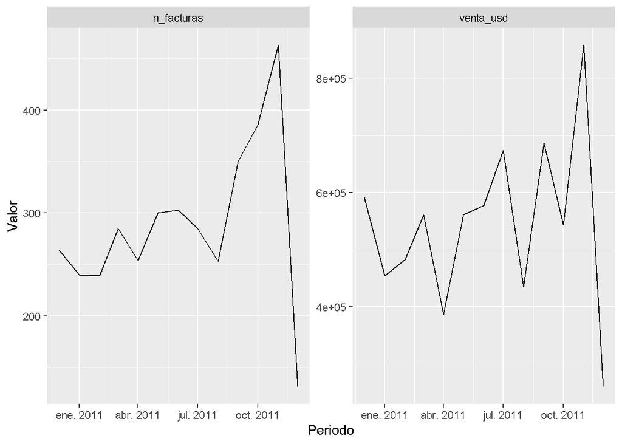

```r
options("openxlsx.numFmt" = "#,##0")

class(dt_porProducto$VarDic)<- "formula"
class(dt_porProducto$VarProm2011)<- "formula"

class(dt_porProducto$Dic_2011)<- "CURRENCY"

{
  wb1 <- createWorkbook()


  addWorksheet(wb1, 'Reporte1', zoom = 80, gridLines = F, tabColour = colours()[sample(1:length(colours()),1)])
  addWorksheet(wb1, 'Reporte2', zoom = 80, gridLines = F, tabColour = colours()[sample(1:length(colours()),1)])
  addWorksheet(wb1, 'Reporte3', zoom = 80, gridLines = F, tabColour = colours()[sample(1:length(colours()),1)])

  insertImage(wb1, 1, "Data/TOP.png", startRow = 1,startCol = 1, height = 1.02, width = 26, units = "cm")
  insertImage(wb1, 2, "Data/TOP.png", startRow = 1,startCol = 1, height = 1.02, width = 26, units = "cm")
  insertImage(wb1, 3, "Data/TOP.png", startRow = 1,startCol = 1, height = 1.02, width = 26, units = "cm")

  writeData(wb = wb1, sheet = 1, x = "Reporte de los países", withFilter=FALSE, xy = c("A", 3),colNames=FALSE)
  writeData(wb = wb1, sheet = 2, x = 'Reporte de Reino Unido', withFilter=FALSE,xy = c("A", 3),colNames=FALSE)
  writeData(wb = wb1, sheet = 3, x = 'Reporte por producto', withFilter=FALSE,xy = c("A", 3),colNames=FALSE)

  writeData(wb1, 1, rpt_porPais, withFilter = T, xy = c("A", 5), headerStyle = hs2)

  writeDataTable(wb1, 2, dt_UnitedKingdom, withFilter=TRUE, xy = c("A", 5), tableName = 'Reporte2', firstColumn = T, bandedRows = T,
                 tableStyle = "TableStyleMedium2", lastColumn = FALSE)
  writeDataTable(wb1, 3, dt_porProducto, withFilter=TRUE, xy = c("A", 5), tableName = 'Reporte3', firstColumn = T, bandedRows = F, bandedCols = T,
                 headerStyle = hs2, lastColumn = TRUE)

  freezePane(wb = wb1, sheet = 1, firstActiveRow = 6, firstActiveCol = 3)
  freezePane(wb = wb1, sheet = 2, firstActiveRow = 6, firstActiveCol = 3)
  freezePane(wb = wb1, sheet = 3, firstActiveRow = 6, firstActiveCol = 3)

  mergeCells(wb = wb1, sheet = 1, cols = 1:ncol(rpt_porPais), rows = 3)
  mergeCells(wb = wb1, sheet = 2, cols = 1:ncol(dt_UnitedKingdom), rows = 3)
  mergeCells(wb = wb1, sheet = 3, cols = 1:ncol(dt_porProducto), rows = 3)

  addStyle(wb1, 1, hs, rows = 3, cols = 1:ncol(rpt_porPais), gridExpand = T)
  addStyle(wb1, 2, hs, rows = 3, cols = 1:ncol(dt_UnitedKingdom), gridExpand = T)
  addStyle(wb1, 3, hs, rows = 3, cols = 1:ncol(dt_porProducto), gridExpand = T)

  setRowHeights(wb = wb1, sheet = 3, rows = 5, heights = 40)

  setColWidths(wb = wb1, sheet = 1, cols =  1, 14, ignoreMergedCells = T)
  setColWidths(wb = wb1, sheet = 1, cols =  4:15, 7, ignoreMergedCells = T)
  setColWidths(wb = wb1, sheet = 1, cols =  3, hidden = T)

  setColWidths(wb = wb1, sheet = 2, cols =  1, 'auto', ignoreMergedCells = T)
  setColWidths(wb = wb1, sheet = 2, cols =  2:(ncol(dt_UnitedKingdom)), 10, ignoreMergedCells = T)

  setColWidths(wb = wb1, sheet = 3, cols =  1:2, 'auto', ignoreMergedCells = T)
  setColWidths(wb = wb1, sheet = 3, cols =  3:(ncol(dt_porProducto)), 10, ignoreMergedCells = T)

  addStyle(wb1, 3, sty_curr, rows = (1:nrow(dt_porProducto))+5, cols = which(names(dt_porProducto)=='Dic_2010'))
  addStyle(wb1, 3, sty_perc, rows = (1:nrow(dt_porProducto))+5, cols = which(names(dt_porProducto)=='VarDic'))
  addStyle(wb1, 3, sty_perc, rows = (1:nrow(dt_porProducto))+5, cols = which(names(dt_porProducto)=='VarProm2011'))

  conditionalFormatting(wb1,3,cols=which(names(dt_porProducto)=='VarDic'), rows=1:nrow(dt_porProducto)+5,rule='$F6<=0', style = sty_neg)
  conditionalFormatting(wb1,3,cols=which(names(dt_porProducto)=='VarDic'), rows=1:nrow(dt_porProducto)+5,rule='$F6>0', style = sty_pos)

  conditionalFormatting(wb1,3,cols=which(names(dt_porProducto)=='VarProm2011'), rows=1:nrow(dt_porProducto)+5,rule='$G6<=0', style = sty_neg2)
  conditionalFormatting(wb1,3,cols=which(names(dt_porProducto)=='VarProm2011'), rows=1:nrow(dt_porProducto)+5,rule='$G6>0', style = sty_pos2)

  conditionalFormatting(wb1,1,cols=1:ncol(rpt_porPais), rows=1:nrow(rpt_porPais)+5,rule='$A6<>$A5', style = ht1)
  conditionalFormatting(wb1,1,cols=1, rows=1:nrow(rpt_porPais)+5,rule='$A6=$A5', style = ht2)

  graph1 <- rpt_UnitedKingdom %>%
    mutate(Periodo= ymd(Anio*10000+Mes*100+01)) %>%
    pivot_longer(c("venta_usd", "n_facturas"), names_to = "Variable", values_to= "Valor") %>%
    ggplot( aes(x= Periodo)) +
    geom_line( aes(y= Valor)) +
    facet_wrap( "Variable", scales = "free")

  print(graph1)
  insertPlot(wb1, sheet = 2, startRow = 6, startCol = ncol(rpt_UnitedKingdom)+2, width = 15, height = 7.5, units = 'cm')

  comentario_1 <- createComment(
    comment = 'Las columnas de las variaciones son fórmulas de Excel',
    author = Sys.getenv("USERNAME"),
    visible = TRUE,
    width = 2,
    height = 2)

  writeComment(wb = wb1,
               sheet = 'Reporte3',
               col = 9,
               row = 5,
               comment = comentario_1)

  protectWorkbook(wb = wb1, protect = TRUE,
                  lockStructure = TRUE, lockWindows = FALSE)

  protectWorksheet(wb = wb1, sheet = 2, protect = TRUE, password = 'SEE',
                   lockSelectingLockedCells = FALSE,
                   lockSelectingUnlockedCells = FALSE,
                   lockFormattingCells = TRUE,
                   lockFormattingColumns = TRUE,
                   lockFormattingRows = TRUE,
                   lockInsertingColumns = TRUE,
                   lockInsertingRows = TRUE,
                   lockInsertingHyperlinks = TRUE,
                   lockDeletingColumns = TRUE,
                   lockDeletingRows = TRUE,
                   lockSorting  = TRUE,
                   lockAutoFilter  = FALSE,
                   lockPivotTables = TRUE,
                   lockObjects  = TRUE,
                   lockScenarios  = TRUE)

  saveWorkbook(wb = wb1, file = 'Exports/reporte_consolidado.xlsx', overwrite = TRUE)
}
```

## Enviar por mail

En ésta última parte se usará la librería mailR para enviar el archivo xlsx generado vía correo electrónico.

```r
# CORREO ------------------------------------------------------------------

library('mailR')

sender <- "nathalie.tejena@see-ec.org"

recipients <- c("vendedor1@see-ec.org",
                "vendedor2@see-ec.org",
                "vendedor3@see-ec.org",
                "vendedor4@see-ec.org",
                "vendedor5@see-ec.org",
                "vendedor6@see-ec.org",
                "supervisor16@see-ec.org",
                "supervisor2@see-ec.org",
                "nestor.montano@see-ec.org")
copia <- c("bi@see-ec.org")

send.mail(from = sender,
          to = recipients,
          cc = copia,
          subject = paste0("AVANCE VENTAS AL - ",fecha_fin),
          html = TRUE,
          inline=TRUE,
          body =
            paste0(
              '
                Estimados:

                <p>Se adjunta reporte de avance de ventas.</p>
                <br>
                <p>En la primera hoja se muestra el total de los países, en las siguientes hojas detalle por producto.</p>
                <br>

                <p>Quedamos atentos a cualquier duda o sugerencia.</p>
                <br>
                <p>Saludos cordiales,</p>
                <br>
                <b>Nathalie Tejena</b>

                '),
          smtp = list(user.name = "nathalie.tejena@see-ec.org",
                      host.name = "smtp.office365.com",
                      port = 587,
                      passwd = pw,
                      tls=TRUE),
          authenticate = TRUE,
          send = TRUE,
          attach.files = 'Exports/reporte_consolidado.xlsx')
```

## Calendarizar

Finalmente, se debe usar el programador de tareas de windows para calendarizar la ejecución de todo este script; en el video se muestra cómo hacerlo.